# ECON 167 - Linear Regression

# 3. Exogeneity

The exogeneity assumption requires that the error term is uncorrelated with our independent variables.

$$E[\epsilon|X] = 0$$

When this assumption is violated, our coefficient estimates become biased.

```r
# Set sample size and true parameters
n <- 1000
beta0 <- 1
beta1 <- 2

# Generate instrument (z) and error term with common factor
z <- rnorm(n)
epsilon <- 2*z + rnorm(n)  # Error term depends on z

# Generate x1 with endogeneity
x1_endo <- 0.5*z + rnorm(n)  # x1 correlated with z and thus with epsilon

# Generate dependent variable
y_endo <- beta0 + beta1*x1_endo + epsilon

# Generate exogenous case for comparison
x1_exog <- rnorm(n)  # Independent x1
epsilon_exog <- rnorm(n)  # Independent error

y_exog <- beta0 + beta1*x1_exog + epsilon_exog

# Fit both models
model_endo <- lm(y_endo ~ x1_endo)
model_exog <- lm(y_exog ~ x1_exog)

# Create comparison of estimates
results <- data.frame(
  Parameter = c("beta0", "beta1"),
  True_Value = c(beta0, beta1),
  Exogenous_Estimate = coef(model_exog),
  Endogenous_Estimate = coef(model_endo)
)

# Visualize bias
par(mfrow = c(1, 2))
plot(x1_exog, epsilon_exog,
     main = "Exogenous Case: x ⊥ ε",
     xlab = "x", ylab = "ε")
abline(h = 0, col = "red", lty = 2)
```

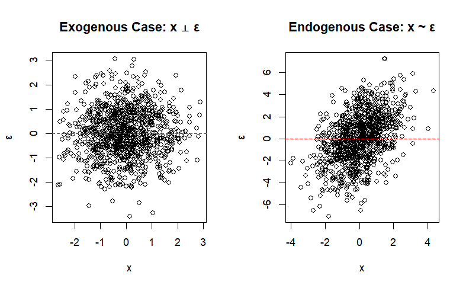

```r
plot(x1_endo, epsilon,
     main = "Endogenous Case: x ~ ε",
     xlab = "x", ylab = "ε")
abline(h = 0, col = "red", lty = 2)
```

|  | Parameter | True_Value | Exogenous_Estimate | Endogenous_Estimate |
| --- | --- | --- | --- | --- |
| (Intercept) | beta0 | 1 | 1.003818 | 0.9942917 |
| x1_exog | beta1 | 2 | 2.032888 | 2.8475568 |

# 4. Spherical Disturbances

This assumption requires homoskedastic errors (constant variance) and no autocorrelation. Mathematically, this means:

$E[\epsilon\epsilon'|X] = \sigma^2I$

The term “spherical” comes from the geometric interpretation: when we plot the multivariate normal density function, the contours form perfect spheres in n-dimensional space.

Let’s focus on heteroskedasticity, where error variance depends on X.

```r
# Generate data with homoskedastic errors
x <- runif(n, -2, 2)
epsilon_homo <- rnorm(n, 0, 1)  # Constant variance
y_homo <- beta0 + beta1*x + epsilon_homo

# Generate heteroskedastic errors where variance increases with x
epsilon_hetero <- rnorm(n, 0, 0.5 + abs(x))  # Variance depends on x
y_hetero <- beta0 + beta1*x + epsilon_hetero

# Fit models
model_homo <- lm(y_homo ~ x)
model_hetero <- lm(y_hetero ~ x)

# Create visualization
par(mfrow = c(2, 2))

# Plot original data
plot(x, y_homo,
     main = "Homoskedastic Data",
     xlab = "x", ylab = "y")
abline(model_homo, col = "blue")
```

```r
plot(x, y_hetero,
     main = "Heteroskedastic Data",
     xlab = "x", ylab = "y")
abline(model_hetero, col = "blue")
```

```r
# Plot residuals
plot(x, residuals(model_homo),
     main = "Homoskedastic Residuals",
     xlab = "x", ylab = "Residuals")
abline(h = 0, col = "red", lty = 2)
```

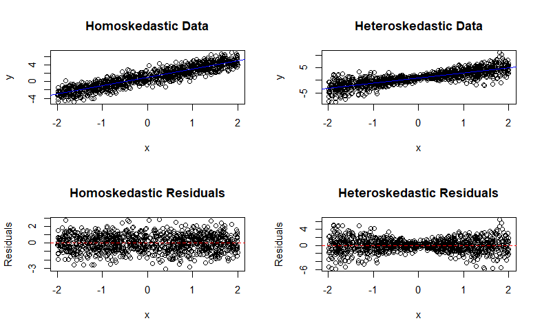

```r
plot(x, residuals(model_hetero),
     main = "Heteroskedastic Residuals",
     xlab = "x", ylab = "Residuals")
abline(h = 0, col = "red", lty = 2)
```

```r
# Perform Breusch-Pagan test
bp_homo <- bptest(model_homo)
bp_hetero <- bptest(model_hetero)

cat("\nBreusch-Pagan test p-values:\n") # test for heteroskedasticity, null hypothesis is that residuals' variance is homoskedastic
```

```
Breusch-Pagan test p-values:
```

```r
cat("Homoskedastic case:", bp_homo$p.value, "\n")
```

```
Homoskedastic case: 0.6796717
```

```r
cat("Heteroskedastic case:", bp_hetero$p.value, "\n") # small p-value => heteroskedasticity
```

```
Heteroskedastic case: 0.1141796
```